# Project 2: House Sales in King County, USA

Spencer Stucky, Cheng Zeng, Wenyu Zeng, Chao Zhou

11/20/2019

# Chapter 1: Introduction

King County locates in Washington state, U.S. It is the most populous county in the state and the 12th-most populous in the country. (Wikipidia.com) Therefore, this project we are using the data from Kaggle about King County’s house sale. This dataset was provided by King County. It includes the house sold in 2014 and 2015. In this project, we will analyze what features relate to the price of house; and we will try to predict house price.

# Chapter 2: Description of Data

```
##        id                        date           price
##  Min.   :1.00e+06   20140623T000000:  142   Min.   :  75000
##  1st Qu.:2.12e+09   20140625T000000:  131   1st Qu.: 321950
##  Median :3.90e+09   20140626T000000:  131   Median : 450000
##  Mean   :4.58e+09   20140708T000000:  127   Mean   : 540088
##  3rd Qu.:7.31e+09   20150427T000000:  126   3rd Qu.: 645000
##  Max.   :9.90e+09   20150325T000000:  123   Max.   :7700000
##                     (Other)        :20833
##     bedrooms      bathrooms     sqft_living       sqft_lot
##  3      :9824   2.5    :5380   Min.   :  290   Min.   :    520
##  4      :6882   1      :3852   1st Qu.: 1427   1st Qu.:   5040
##  2      :2760   1.75   :3048   Median : 1910   Median :   7618
##  5      :1601   2.25   :2047   Mean   : 2080   Mean   :  15107
##  6      : 272   2      :1930   3rd Qu.: 2550   3rd Qu.:  10688
##  1      : 199   1.5    :1446   Max.   :13540   Max.   :1651359
##  (Other):  75   (Other):3910
##  floors      waterfront view      condition     grade        sqft_above
##  1  :10680   0:21450    0:19489   1:   30   7      :8981   Min.   : 290
##  1.5: 1910   1:  163    1:  332   2:  172   8      :6068   1st Qu.:1190
##  2  : 8241              2:  963   3:14031   9      :2615   Median :1560
##  2.5:  161              3:  510   4: 5679   6      :2038   Mean   :1788
##  3  :  613              4:  319   5: 1701   10     :1134   3rd Qu.:2210
##  3.5:    8                                  11     : 399   Max.   :9410
##                                             (Other): 378
##  sqft_basement     yr_built    yr_renovated    zipcode
##  Min.   :   0   Min.   :1900   0:20699      98103  :  602
##  1st Qu.:   0   1st Qu.:1951   1:  914      98038  :  590
##  Median :   0   Median :1975                98115  :  583
##  Mean   : 292   Mean   :1971                98052  :  574
##  3rd Qu.: 560   3rd Qu.:1997                98117  :  553
##  Max.   :4820   Max.   :2015                98042  :  548
##                                             (Other):18163
##       lat              long       sqft_living15    sqft_lot15
##  47.5322:   17   -122.29 :  116   Min.   : 399   Min.   :   651
##  47.5491:   17   -122.3  :  111   1st Qu.:1490   1st Qu.:  5100
##  47.6624:   17   -122.362:  104   Median :1840   Median :  7620
##  47.6846:   17   -122.291:  100   Mean   :1987   Mean   : 12768
##  47.6711:   16   -122.372:   99   3rd Qu.:2360   3rd Qu.: 10083
##  47.6886:   16   -122.363:   99   Max.   :6210   Max.   :871200
##  (Other):21513   (Other) :20984
```

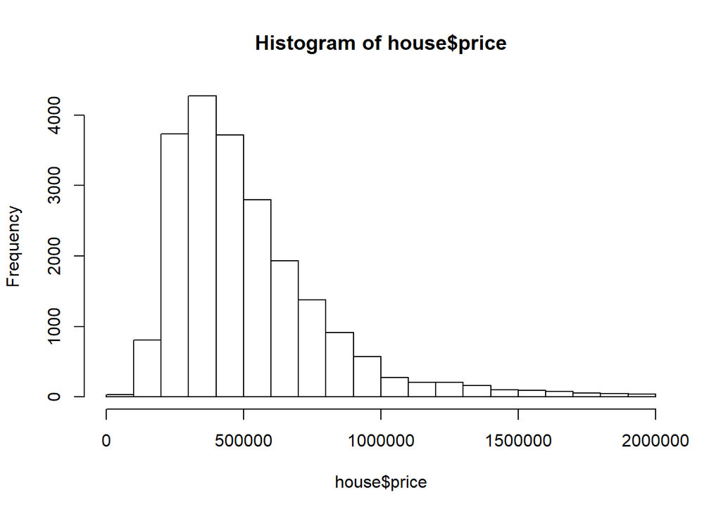

There are 21 variables in this dataset which include all house features in it, such as price, number of bedrooms and bathrooms, dimension, floors, view, grade, condition and years. The view shows from 0 to 4 how good the view of the property, and grade is an index from 1 to 13 to score the building construction and design. After data observation, we decided to exclude the house price that larger than $2million, because this range of house price only takes less than 1% of total house price. Moreover, the original data only shows the year of renovation; thus, we changed the year to 1 if the houses have been renovated and 0 for the houses that have never been renovated. In addition, we change several variables to factors, they are bedrooms, bathrooms, waterfront, view, condition, grade, zip code, latitude and longitude.

```
## 'data.frame':    21415 obs. of  21 variables:
##  $ id           : num  7.13e+09 6.41e+09 5.63e+09 2.49e+09 1.95e+09 ...
##  $ date         : Factor w/ 372 levels "20140502T000000",..: 165 221 291 221 284 11 57 252 340 306 ...
##  $ price        : num  221900 538000 180000 604000 510000 ...
##  $ bedrooms     : Factor w/ 13 levels "0","1","2","3",..: 4 4 3 5 4 5 4 4 4 4 ...
##  $ bathrooms    : Factor w/ 30 levels "0","0.5","0.75",..: 4 9 4 12 8 18 9 6 4 10 ...
##  $ sqft_living  : int  1180 2570 770 1960 1680 5420 1715 1060 1780 1890 ...
##  $ sqft_lot     : int  5650 7242 10000 5000 8080 101930 6819 9711 7470 6560 ...
##  $ floors       : Factor w/ 6 levels "1","1.5","2",..: 1 3 1 1 1 1 3 1 1 3 ...
##  $ waterfront   : Factor w/ 2 levels "0","1": 1 1 1 1 1 1 1 1 1 1 ...
##  $ view         : Factor w/ 5 levels "0","1","2","3",..: 1 1 1 1 1 1 1 1 1 1 ...
##  $ condition    : Factor w/ 5 levels "1","2","3","4",..: 3 3 3 5 3 3 3 3 3 3 ...
##  $ grade        : Factor w/ 12 levels "1","3","4","5",..: 6 6 5 6 7 10 6 6 6 6 ...
##  $ sqft_above   : int  1180 2170 770 1050 1680 3890 1715 1060 1050 1890 ...
##  $ sqft_basement: int  0 400 0 910 0 1530 0 0 730 0 ...
##  $ yr_built     : int  1955 1951 1933 1965 1987 2001 1995 1963 1960 2003 ...
##  $ yr_renovated : Factor w/ 2 levels "0","1": 1 2 1 1 1 1 1 1 1 1 ...
##  $ zipcode      : Factor w/ 70 levels "98001","98002",..: 67 56 17 59 38 30 3 69 61 24 ...
##  $ lat          : Factor w/ 5034 levels "47.1559","47.1593",..: 2399 4479 4648 2493 3440 3832 562 1464 2410 1102 ...
##  $ long         : Factor w/ 752 levels "-122.519","-122.515",..: 224 162 248 88 436 476 154 166 144 450 ...
##  $ sqft_living15: int  1340 1690 2720 1360 1800 4760 2238 1650 1780 2390 ...
##  $ sqft_lot15   : int  5650 7639 8062 5000 7503 101930 6819 9711 8113 7570 ...
```

Above is the structure of our dataset after changes. From this structure display we can see there are 70 different zip code, 5034 latitude and 752 longitude in this dataset. Thereby, we won’t include these three factors in our further model and analysis.

## EDA

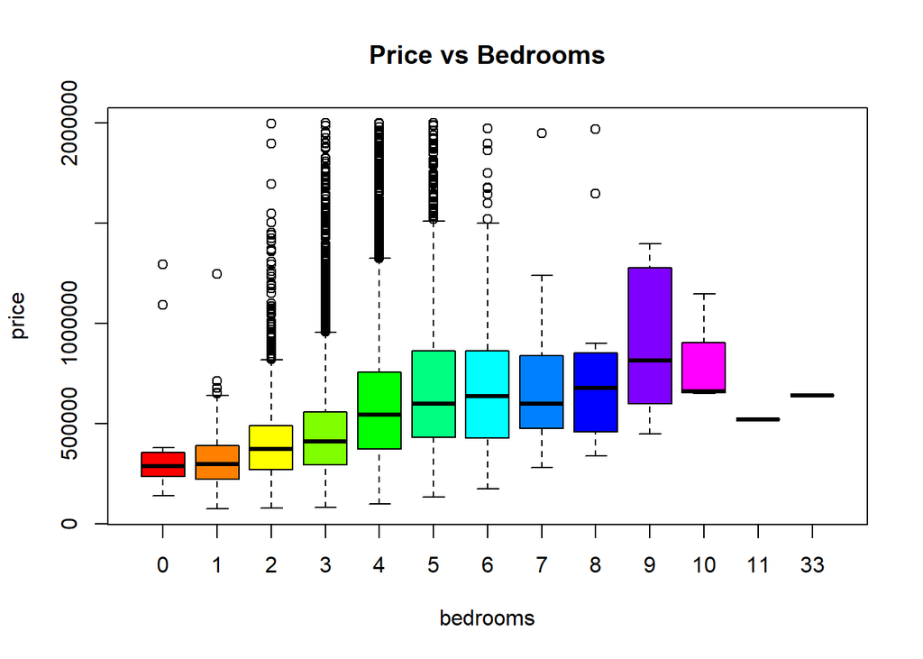

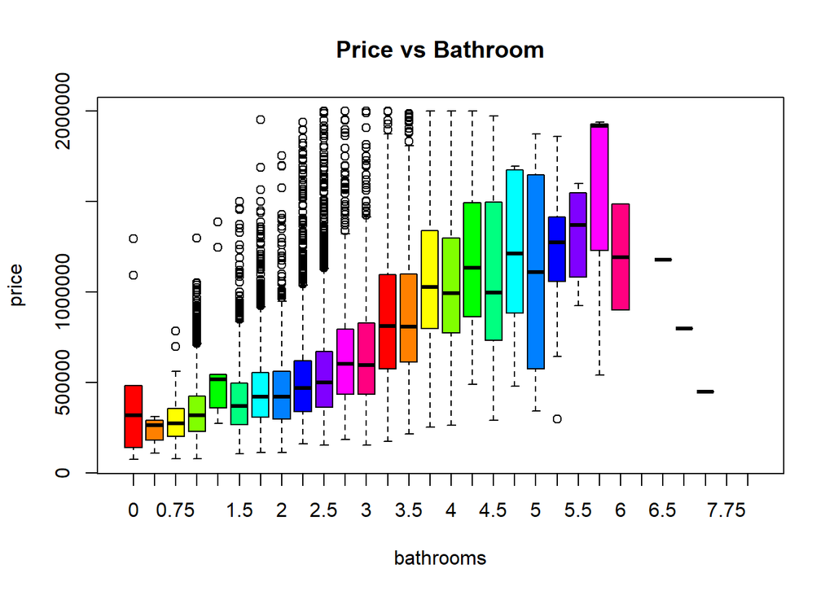

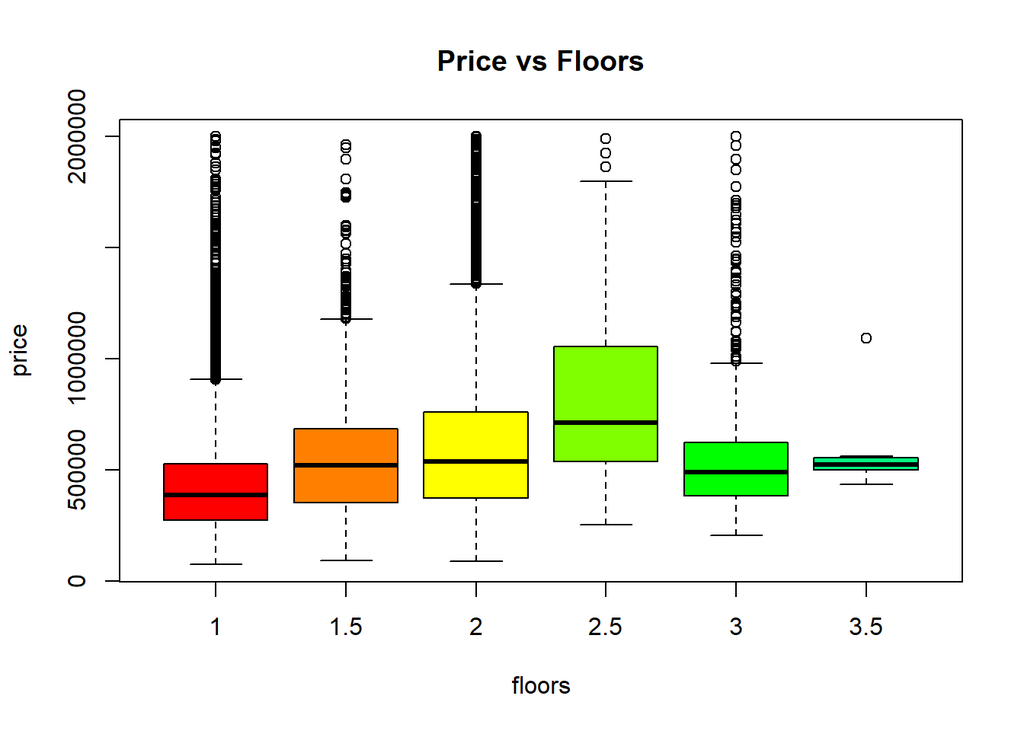

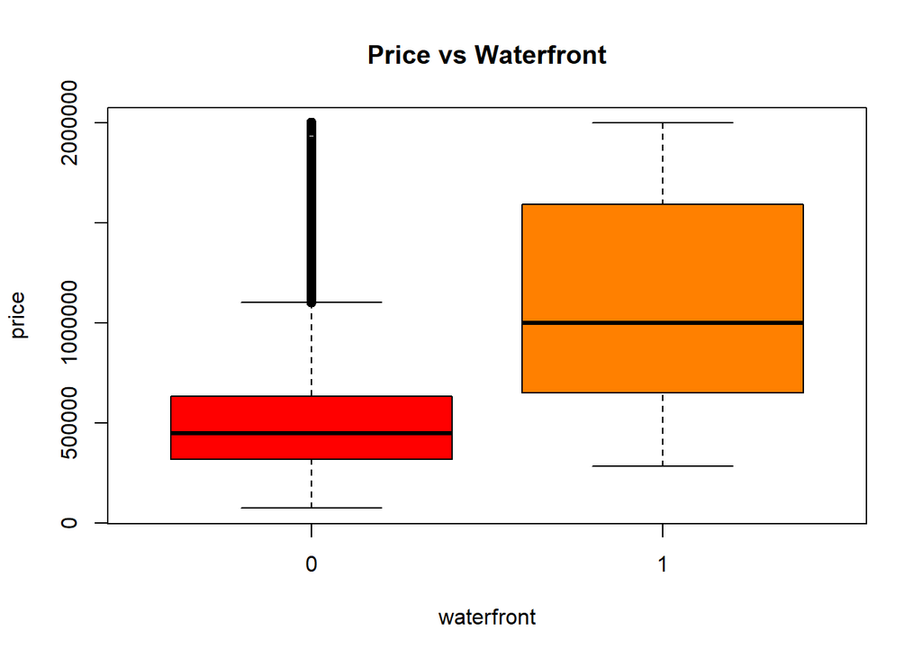

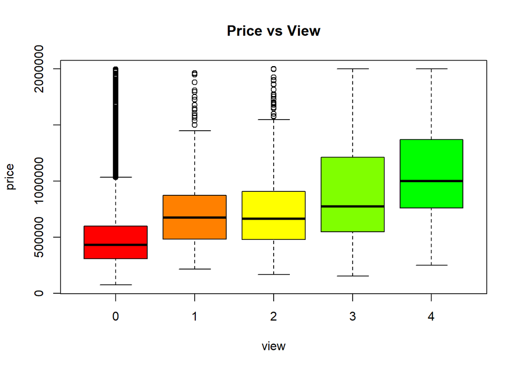

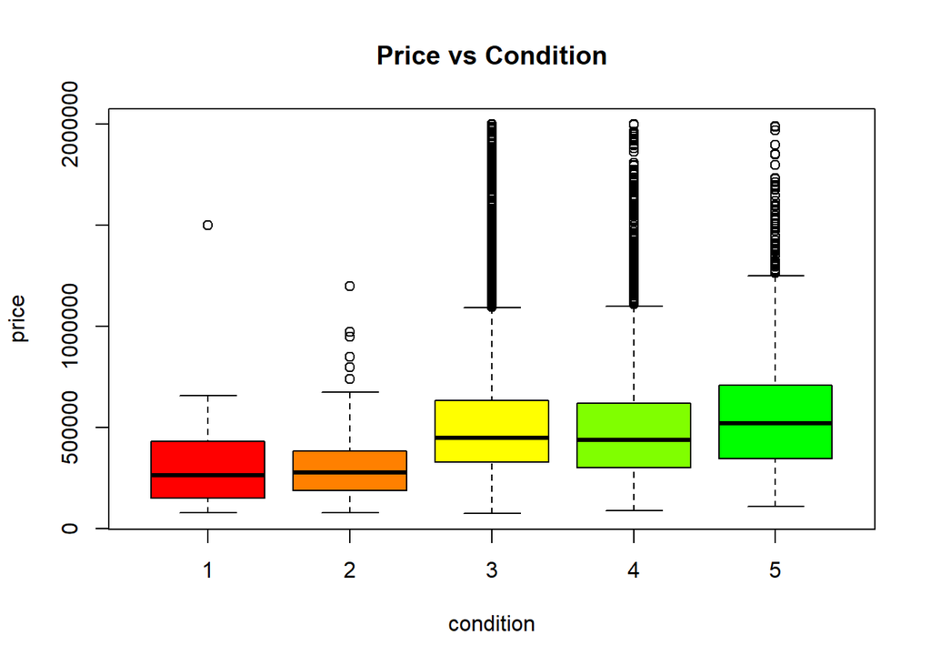

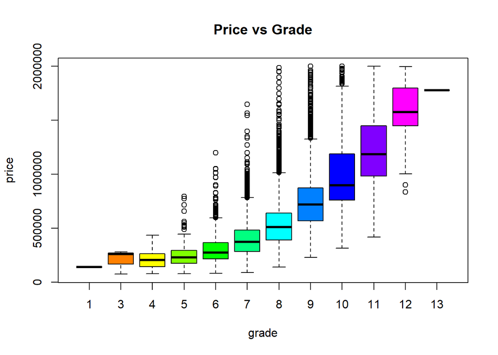

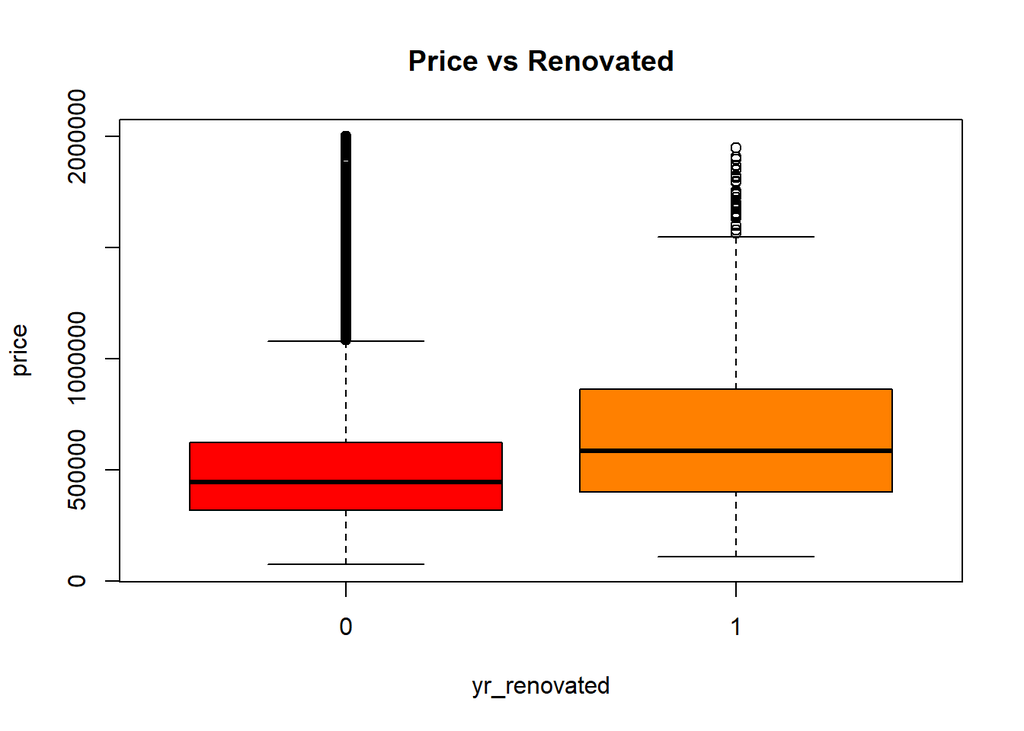

# Chapter 3

## S.M.A.R.T. Question

What features are associated with housing prices for King County, WA?

## ANOVA Test

In order to check which variable that associated with housing price, we are using anova test. Before we run the test, our hull hypothesis is price of house with different features are equal.

```
##                  Df   Sum Sq  Mean Sq F value  Pr(>F)
## bedrooms         12 2.01e+14 1.68e+13   598.8 < 2e-16 ***
## bathrooms        26 3.38e+14 1.30e+13   464.3 < 2e-16 ***
## sqft_living       1 3.34e+14 3.34e+14 11906.6 < 2e-16 ***
## sqft_lot          1 1.33e+12 1.33e+12    47.4 5.9e-12 ***
## floors            5 2.00e+13 4.00e+12   142.6 < 2e-16 ***
## waterfront        1 2.36e+13 2.36e+13   841.3 < 2e-16 ***
## view              4 3.76e+13 9.40e+12   335.3 < 2e-16 ***
## condition         4 1.21e+13 3.03e+12   108.0 < 2e-16 ***
## grade            11 1.30e+14 1.18e+13   421.2 < 2e-16 ***
## sqft_above        1 3.48e+12 3.48e+12   124.1 < 2e-16 ***
## yr_built          1 6.32e+13 6.32e+13  2255.5 < 2e-16 ***
## yr_renovated      1 6.15e+11 6.15e+11    21.9 2.8e-06 ***
## sqft_living15     1 8.80e+12 8.80e+12   314.0 < 2e-16 ***
## sqft_lot15        1 1.11e+12 1.11e+12    39.6 3.1e-10 ***
## Residuals     21344 5.98e+14 2.80e+10
## ---
## Signif. codes:  0 '***' 0.001 '**' 0.01 '*' 0.05 '.' 0.1 ' ' 1
```

# Chapter 4 Linear Models

## Introduction to Linear Models

In this section we wanted to look at which housing features most affected housing prices in King County, WA. From our analysis, we wanted to be able to build a model that most accurately could describe and hence predict housing sales in the county. Each model is a linear regression on the price at which the house sold.

Each model takes a different approach to explaining house prices. The first looks at basic categorical variables that desrcibe the house or its appearance using grade, view, condition, waterfront, bedroom, and bathroom variables. The idea here was to exlcude numeric variables such as square footage and the variables desrcibing surrounding houses to just focus on the more simplistic aspects of the house itself.

The second model focuses on the numeric values of square feet for both the house itself and the surrounding 15 houses. The “15” variables are the average square feet of the surrounding 15 houses, for both living space and lot space, to give an idea of what the neighborhood housing size is like. The third model looks at year built and renovated to see if it effects housing price. As it turns out, as the analysis explains below, this was a poor model for explaining the results of our target variable.

From here, we chose a backward-step selection process for input variables. Model 4 uses all variables to test how all of them effect housing price. Then, we wanted to adjust the model to get the highest R2 with most significant variables. More importantly, we needed to remove some variables that either didn’t make sense with our model analysis or they displayed high multicollinearity. We then move to model 5, which utilized backward step selection to remove some variables. Specifically, it tested all relevant variables except for square feet above and square feet basement because they were multicollinear. As well, this model excluded zip code, latitude, and longitude because they did not work for our model and couldn’t explain price well because they were difficult to measure. This was the best model we reached for explaining our target variable, price, with all relevant variables.

## Correlation Plots

```
## 'data.frame':    21415 obs. of  9 variables:
##  $ sqft_lot     : int  5650 7242 10000 5000 8080 101930 6819 9711 7470 6560 ...
##  $ sqft_living  : int  1180 2570 770 1960 1680 5420 1715 1060 1780 1890 ...
##  $ sqft_above   : int  1180 2170 770 1050 1680 3890 1715 1060 1050 1890 ...
##  $ sqft_basement: int  0 400 0 910 0 1530 0 0 730 0 ...
##  $ sqft_living15: int  1340 1690 2720 1360 1800 4760 2238 1650 1780 2390 ...
##  $ sqft_lot15   : int  5650 7639 8062 5000 7503 101930 6819 9711 8113 7570 ...
##  $ yr_renovated : num  1 2 1 1 1 1 1 1 1 1 ...
##  $ yr_built     : int  1955 1951 1933 1965 1987 2001 1995 1963 1960 2003 ...
##  $ price        : num  221900 538000 180000 604000 510000 ...
```

```
##               sqft_lot sqft_living sqft_above sqft_basement sqft_living15
## sqft_lot       1.00000      0.1744     0.1841        0.0109        0.1454
## sqft_living    0.17443      1.0000     0.8682        0.4066        0.7547
## sqft_above     0.18406      0.8682     1.0000       -0.1004        0.7279
## sqft_basement  0.01086      0.4066    -0.1004        1.0000        0.1731
## sqft_living15  0.14535      0.7547     0.7279        0.1731        1.0000
## sqft_lot15     0.71712      0.1847     0.1941        0.0129        0.1833
## yr_renovated   0.00722      0.0413     0.0118        0.0610       -0.0165
## yr_built       0.05270      0.3387     0.4434       -0.1373        0.3379
## price          0.10146      0.6800     0.5853        0.2859        0.6017
##               sqft_lot15 yr_renovated yr_built  price
## sqft_lot         0.71712      0.00722   0.0527 0.1015
## sqft_living      0.18471      0.04131   0.3387 0.6800
## sqft_above       0.19413      0.01183   0.4434 0.5853
## sqft_basement    0.01294      0.06105  -0.1373 0.2859
## sqft_living15    0.18329     -0.01646   0.3379 0.6017
## sqft_lot15       1.00000      0.00666   0.0702 0.0903
## yr_renovated     0.00666      1.00000  -0.2243 0.1171
## yr_built         0.07020     -0.22432   1.0000 0.0647
## price            0.09026      0.11711   0.0647 1.0000
```

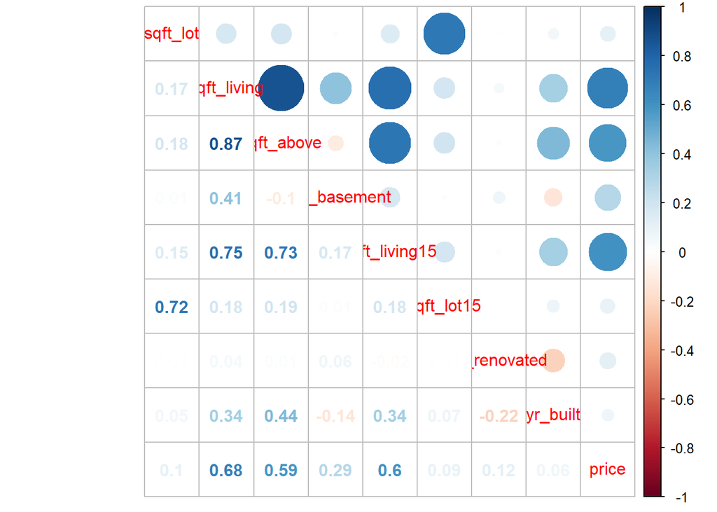

## Linear Models

### Model 1

```
##
## Call:
## lm(formula = price ~ grade + view + condition + waterfront +
##     bedrooms + bathrooms, data = house)
##
## Residuals:
##     Min      1Q  Median      3Q     Max
## -970455 -116678  -20954   88545 1257436
##
## Coefficients:
##               Estimate Std. Error t value Pr(>|t|)
## (Intercept)     142000     186315    0.76  0.44598
## grade3           51417     225624    0.23  0.81974
## grade4           87713     204557    0.43  0.66808
## grade5           80075     201968    0.40  0.69176
## grade6          139971     201817    0.69  0.48797
## grade7          234191     201784    1.16  0.24582
## grade8          357300     201796    1.77  0.07664 .
## grade9          549866     201831    2.72  0.00645 **
## grade10         734760     201885    3.64  0.00027 ***
## grade11         912981     202093    4.52  6.3e-06 ***
## grade12        1205921     203027    5.94  2.9e-09 ***
## grade13        1508359     274774    5.49  4.1e-08 ***
## view1           152179      10570   14.40  < 2e-16 ***
## view2           106833       6328   16.88  < 2e-16 ***
## view3           171047       8746   19.56  < 2e-16 ***
## view4           274507      14164   19.38  < 2e-16 ***
## condition2      -46040      37547   -1.23  0.22014
## condition3      -31933      34920   -0.91  0.36049
## condition4       18000      34947    0.52  0.60651
## condition5       93882      35155    2.67  0.00758 **
## waterfront1     242171      20710   11.69  < 2e-16 ***
## bedrooms1        29817      70453    0.42  0.67214
## bedrooms2        46055      69800    0.66  0.50938
## bedrooms3        27310      69760    0.39  0.69545
## bedrooms4        62555      69785    0.90  0.37005
## bedrooms5        99521      69934    1.42  0.15473
## bedrooms6       103065      70773    1.46  0.14533
## bedrooms7        62945      77423    0.81  0.41622
## bedrooms8       247742      89745    2.76  0.00578 **
```

[output cut: 21 more lines]

```
## bathrooms4.75   215292     105106    2.05  0.04054 *
## bathrooms5      147131      98821    1.49  0.13653
## bathrooms5.25   221111     107624    2.05  0.03994 *
## bathrooms5.5    212447     127960    1.66  0.09688 .
## bathrooms5.75   216316     139634    1.55  0.12136
## bathrooms6     -444287     159770   -2.78  0.00543 **
## bathrooms6.5     53887     206246    0.26  0.79388
## bathrooms6.75  -392826     208677   -1.88  0.05979 .
## bathrooms7.5   -259934     222011   -1.17  0.24169
## ---
## Signif. codes:  0 '***' 0.001 '**' 0.01 '*' 0.05 '.' 0.1 ' ' 1
##
## Residual standard error: 186000 on 21356 degrees of freedom
## Multiple R-squared:  0.582,  Adjusted R-squared:  0.581
## F-statistic:  513 on 58 and 21356 DF,  p-value: <2e-16
```

```
##   (Intercept)        grade3        grade4        grade5        grade6
##        142000         51417         87713         80074        139971
##        grade7        grade8        grade9       grade10       grade11
##        234191        357300        549866        734760        912981
##       grade12       grade13         view1         view2         view3
##       1205921       1508359        152179        106833        171047
##         view4    condition2    condition3    condition4    condition5
##        274507        -46040        -31932         18000         93882
##   waterfront1     bedrooms1     bedrooms2     bedrooms3     bedrooms4
##        242171         29817         46055         27310         62555
##     bedrooms5     bedrooms6     bedrooms7     bedrooms8     bedrooms9
##         99521        103065         62945        247742        365676
##    bedrooms10    bedrooms11    bedrooms33  bathrooms0.5 bathrooms0.75
##        218727        136658        187415       -110625        -68610
##    bathrooms1 bathrooms1.25  bathrooms1.5 bathrooms1.75    bathrooms2
##        -31596        -30093        -31859        -17487        -13524
## bathrooms2.25  bathrooms2.5 bathrooms2.75    bathrooms3 bathrooms3.25
##         -9142        -38359         17134         39084         99019
##  bathrooms3.5 bathrooms3.75    bathrooms4 bathrooms4.25  bathrooms4.5
##         85437        209567        139401        197055        172431
## bathrooms4.75    bathrooms5 bathrooms5.25  bathrooms5.5 bathrooms5.75
##        215292        147131        221111        212447        216316
##    bathrooms6  bathrooms6.5 bathrooms6.75  bathrooms7.5
##       -444287         53887       -392826       -259934
```

```
##                 2.5 %  97.5 %
## (Intercept)   -223191  507191
## grade3        -390824  493657
## grade4        -313235  488660
## grade5        -315797  475946
## grade6        -255605  535546
## grade7        -161322  629703
## grade8         -38235  752836
## grade9         154263  945470
## grade10        339050 1130469
## grade11        516863 1309098
## grade12        807974 1603869
## grade13        969781 2046936
## view1          131462  172897
## view2           94429  119236
## view3          153905  188189
## view4          246744  302269
## condition2    -119634   27554
## condition3    -100379   36514
## condition4     -50499   86500
## condition5      24975  162788
## waterfront1    201578  282764
## bedrooms1     -108276  167910
## bedrooms2      -90757  182868
## bedrooms3     -109425  164045
## bedrooms4      -74229  199338
## bedrooms5      -37554  236596
## bedrooms6      -35656  241787
## bedrooms7      -88809  214700
## bedrooms8       71835  423648
## bedrooms9      151836  579515
## bedrooms10     -36127  473581
## bedrooms11    -253545  526861
## bedrooms33    -202669  577499
## bathrooms0.5  -360215  138965
## bathrooms0.75 -242918  105697
## bathrooms1    -201919  138727
## bathrooms1.25 -239209  179022
## bathrooms1.5  -202292  138573
## bathrooms1.75 -187853  152879
## bathrooms2    -183969  156920
## bathrooms2.25 -179574  161290
## bathrooms2.5  -208649  131931
## bathrooms2.75 -153472  187740
## bathrooms3    -131729  209897
## bathrooms3.25  -71979  270018
## bathrooms3.5   -85425  256300
## bathrooms3.75   36447  382688
## bathrooms4     -34318  313121
## bathrooms4.25   20225  373885
## bathrooms4.5    -2513  347374
## bathrooms4.75    9276  421309
## bathrooms5     -46564  340827
## bathrooms5.25   10161  432062
## bathrooms5.5   -38364  463258
## bathrooms5.75  -57378  490009
## bathrooms6    -757448 -131126
## bathrooms6.5  -350371  458145
## bathrooms6.75 -801849   16197
## bathrooms7.5  -695092  175225
```

```
##        grade3        grade4        grade5        grade6        grade7
##          4.40         34.91        281.16       2163.67       6116.24
##        grade8        grade9       grade10       grade11       grade12
##       5098.78       2677.99       1198.82        381.14         67.50
##       grade13         view1         view2         view3         view4
##          2.17          1.01          1.03          1.04          1.46
##    condition2    condition3    condition4    condition5   waterfront1
##          6.89        171.24        146.06         54.85          1.44
##     bedrooms1     bedrooms2     bedrooms3     bedrooms4     bedrooms5
##         28.19        337.34        745.07        650.65        201.85
##     bedrooms6     bedrooms7     bedrooms8     bedrooms9    bedrooms10
##         37.06          5.69          2.55          2.06          1.46
##    bedrooms11    bedrooms33  bathrooms0.5 bathrooms0.75    bathrooms1
##          1.14          1.14          1.87         16.35        687.19
## bathrooms1.25  bathrooms1.5 bathrooms1.75    bathrooms2 bathrooms2.25
##          2.95        293.68        568.62        382.35        402.17
##  bathrooms2.5 bathrooms2.75    bathrooms3 bathrooms3.25  bathrooms3.5
##        874.20        243.54        155.69        119.16        150.68
## bathrooms3.75    bathrooms4 bathrooms4.25  bathrooms4.5 bathrooms4.75
##         31.70         26.33         14.03         20.11          3.18
##    bathrooms5 bathrooms5.25  bathrooms5.5 bathrooms5.75    bathrooms6
##          4.50          3.00          1.89          1.68          1.47
##  bathrooms6.5 bathrooms6.75  bathrooms7.5
##          1.23          1.25          1.42
```

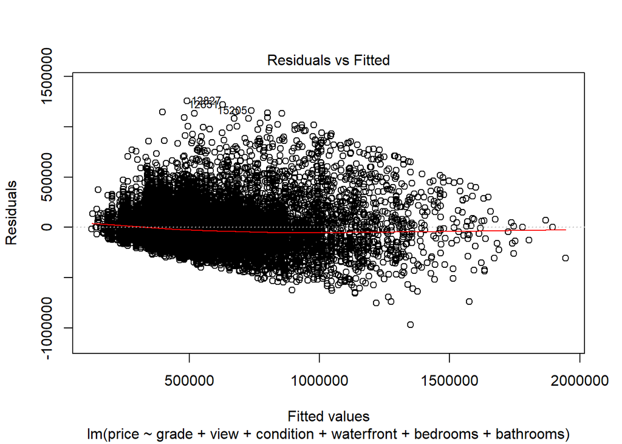

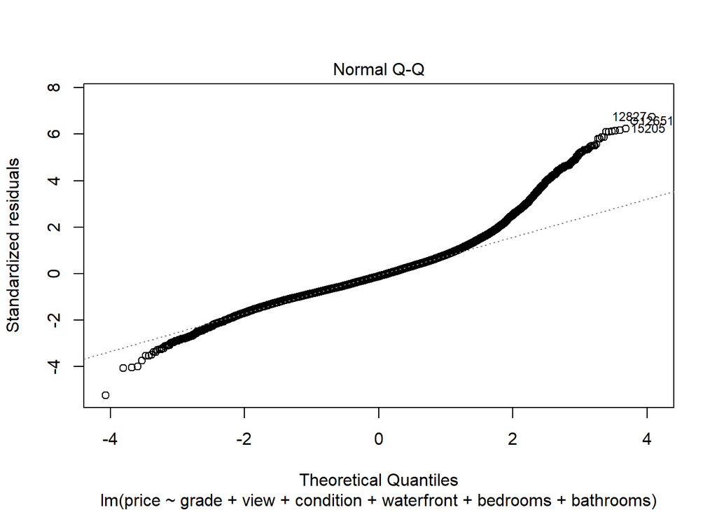

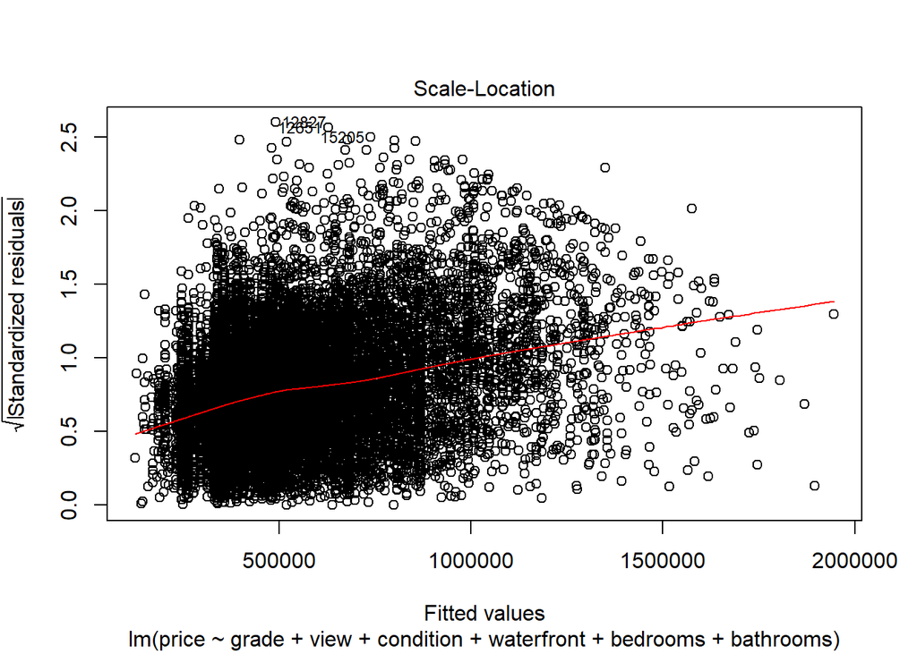

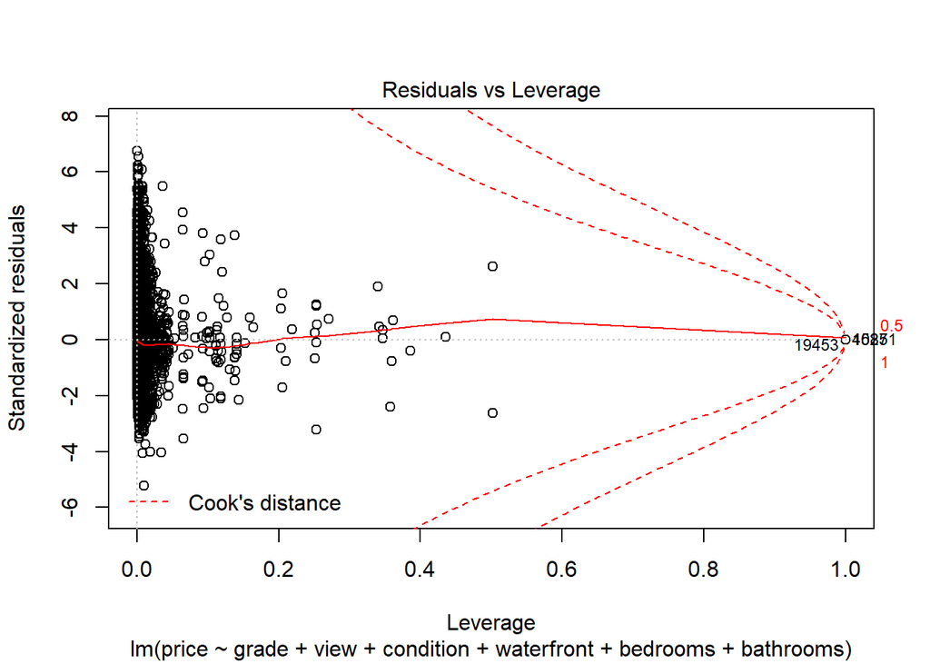

In this model, we first wanted to look at the categorical variables for house, exterior factors, and ranking. R2 is 58% thus model explains 58% of target variable. Upper levels of grade, bedroom, bathroom, and condition are signficant, as well as all factor levels of view and waterfront. Categorical variables of grade, view, condition, bedrooms, and waterfront are positively correlated with price, except for condition 2 and 3 and quite a few number of bathroom levels, which are negatively correlated with price.

### Model 2

```
##
## Call:
## lm(formula = price ~ sqft_lot + sqft_living + sqft_above + sqft_living15 +
##     sqft_lot15, data = house)
##
## Residuals:
##     Min      1Q  Median      3Q     Max
## -757512 -134195  -21473   98140 1336480
##
## Coefficients:
##                Estimate Std. Error t value Pr(>|t|)
## (Intercept)   -1.56e+04   4.41e+03   -3.53  0.00041 ***
## sqft_lot       1.80e-01   4.91e-02    3.67  0.00025 ***
## sqft_living    1.96e+02   3.53e+00   55.49  < 2e-16 ***
## sqft_above    -2.97e+01   3.69e+00   -8.05  8.4e-16 ***
## sqft_living15  9.67e+01   3.31e+00   29.22  < 2e-16 ***
## sqft_lot15    -6.56e-01   7.46e-02   -8.79  < 2e-16 ***
## ---
## Signif. codes:  0 '***' 0.001 '**' 0.01 '*' 0.05 '.' 0.1 ' ' 1
##
## Residual standard error: 207000 on 21409 degrees of freedom
## Multiple R-squared:  0.485,  Adjusted R-squared:  0.484
## F-statistic: 4.02e+03 on 5 and 21409 DF,  p-value: <2e-16
```

```
##   (Intercept)      sqft_lot   sqft_living    sqft_above sqft_living15
##     -1.56e+04      1.80e-01      1.96e+02     -2.97e+01      9.67e+01
##    sqft_lot15
##     -6.56e-01
```

```
##                   2.5 %    97.5 %
## (Intercept)   -2.42e+04 -6935.710
## sqft_lot       8.38e-02     0.276
## sqft_living    1.89e+02   202.987
## sqft_above    -3.69e+01   -22.477
## sqft_living15  9.02e+01   103.193
## sqft_lot15    -8.03e-01    -0.510
```

```
##      sqft_lot   sqft_living    sqft_above sqft_living15    sqft_lot15
##          2.07          4.67          4.29          2.46          2.09
```

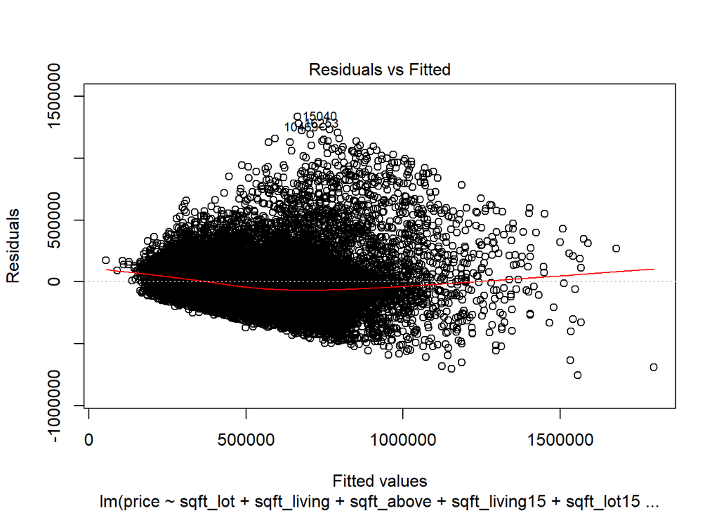

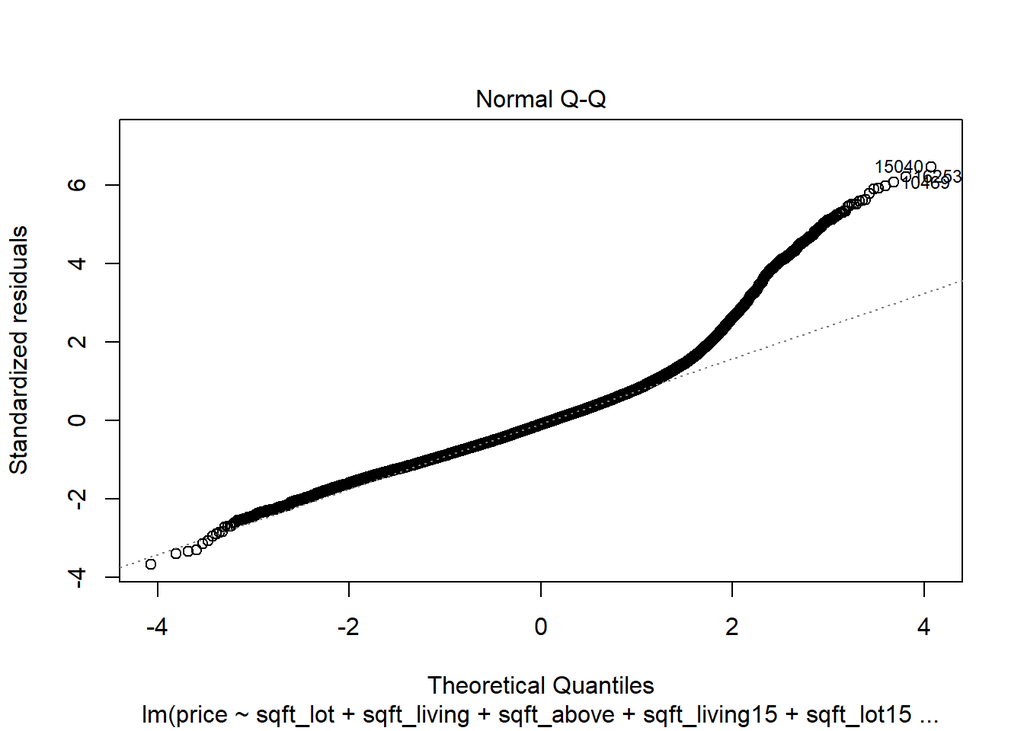

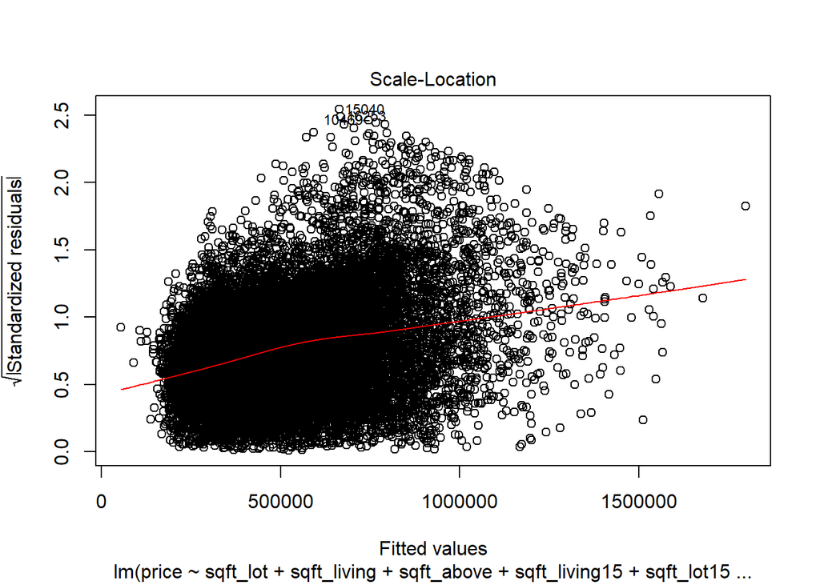

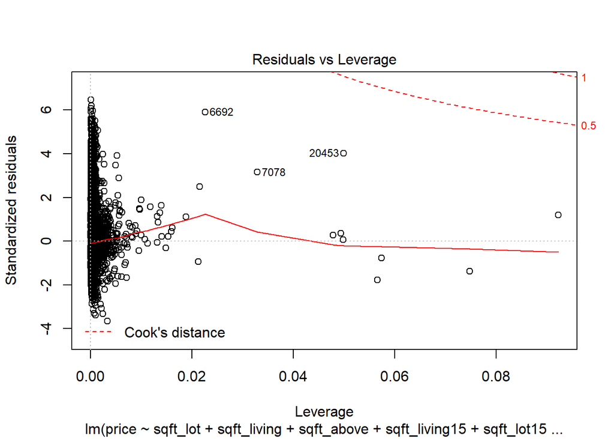

Idea behind this model was to look at sq footage and size of house and surrounding neighborhood to determine if they effect price in some way. Also to look at how these sq ft variables may be collinear and relate to one another. Sqft basement produced NA values and was removed from model. Some moderately high VIFs for sqft living and sqft above - most likely some collinearity there. R2 is 48% thus model explains 48% of results seen in data. All p values are significant. Sq ft lot, sqft living, and sq ft living 15 are positively correlated with price while sqft above and sqft lot 15 are negatively correlated with price.

### Model 3

```
##
## Call:
## lm(formula = price ~ yr_built + yr_renovated, data = house)
##
## Residuals:
##     Min      1Q  Median      3Q     Max
## -599055 -199701  -66957  117750 1543719
##
## Coefficients:
##                Estimate Std. Error t value Pr(>|t|)
## (Intercept)   -1.34e+06   1.34e+05   -9.99   <2e-16 ***
## yr_built       9.40e+02   6.81e+01   13.81   <2e-16 ***
## yr_renovated2  2.01e+05   1.00e+04   19.99   <2e-16 ***
## ---
## Signif. codes:  0 '***' 0.001 '**' 0.01 '*' 0.05 '.' 0.1 ' ' 1
##
## Residual standard error: 285000 on 21412 degrees of freedom
## Multiple R-squared:  0.0224, Adjusted R-squared:  0.0223
## F-statistic:  246 on 2 and 21412 DF,  p-value: <2e-16
```

```
##   (Intercept)      yr_built yr_renovated2
##      -1341947           940        200722
```

```
##                  2.5 %   97.5 %
## (Intercept)   -1605178 -1078715
## yr_built           807     1074
## yr_renovated2   181039   220405
```

```
##      yr_built yr_renovated2
##          1.05          1.05
```

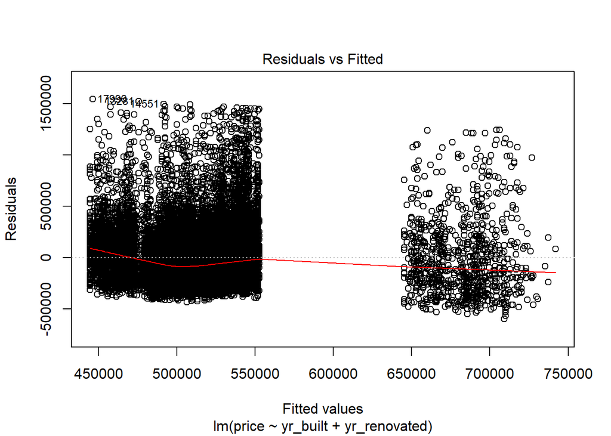

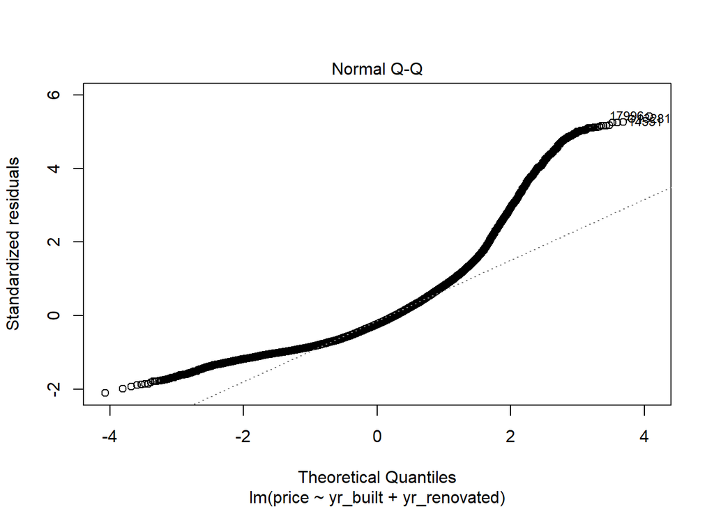

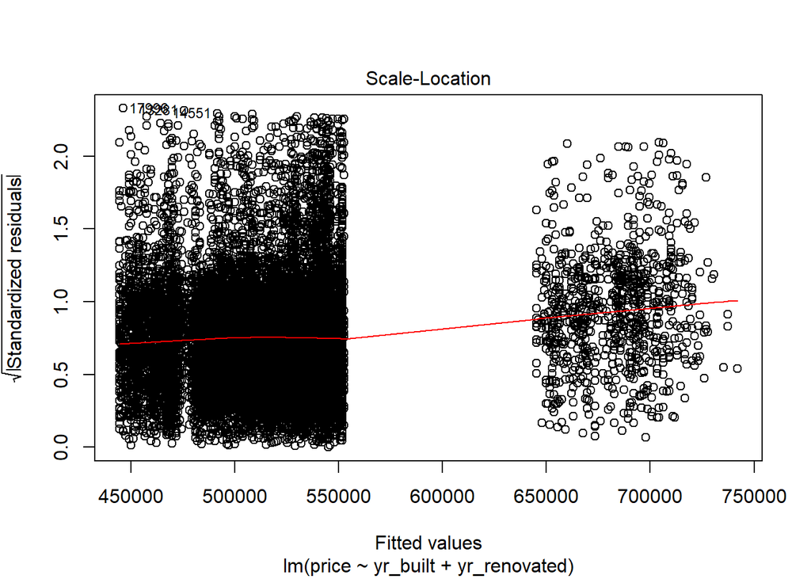

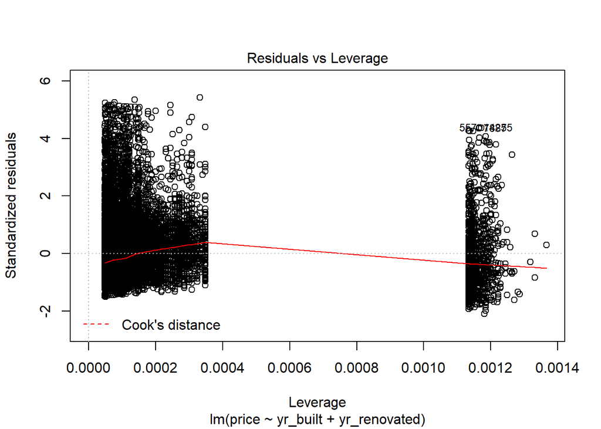

Idea behind this model was to look at yr built and yr renovated of housing to see if they determined something about price. All are highly signficant at .001 level. Year built and Yr renovated were positively correlated with price, with yr built increasing price by 940. R2 is very low at 2.2% thus model does not do a good job of explaining results in data.

### Model 4

```
##
## Call:
## lm(formula = price ~ bedrooms + bathrooms + floors + grade +
##     view + condition + waterfront + sqft_living + sqft_lot +
##     sqft_above + sqft_living15 + sqft_lot15 + yr_built + yr_renovated +
##     sqft_basement, data = house)
##
## Residuals:
##     Min      1Q  Median      3Q     Max
## -811810  -99585  -10711   80814 1124546
##
## Coefficients: (1 not defined because of singularities)
##                Estimate Std. Error t value Pr(>|t|)
## (Intercept)    5.47e+06   2.09e+05   26.12  < 2e-16 ***
## bedrooms1      3.29e+04   6.34e+04    0.52  0.60386
## bedrooms2      5.07e+04   6.28e+04    0.81  0.41916
## bedrooms3      1.52e+04   6.28e+04    0.24  0.80825
## bedrooms4     -1.26e+03   6.28e+04   -0.02  0.98403
## bedrooms5      8.76e+02   6.29e+04    0.01  0.98889
## bedrooms6     -3.59e+04   6.37e+04   -0.56  0.57364
## bedrooms7     -8.31e+04   6.97e+04   -1.19  0.23356
## bedrooms8      6.36e+04   8.08e+04    0.79  0.43142
## bedrooms9      1.04e+04   9.84e+04    0.11  0.91579
## bedrooms10     3.10e+04   1.17e+05    0.27  0.79066
## bedrooms11    -1.74e+05   1.79e+05   -0.97  0.32998
## bedrooms33     1.91e+05   1.79e+05    1.07  0.28679
## bathrooms0.5  -8.73e+04   1.15e+05   -0.76  0.44652
## bathrooms0.75 -7.27e+03   8.02e+04   -0.09  0.92782
## bathrooms1     2.34e+03   7.84e+04    0.03  0.97622
## bathrooms1.25  7.62e+04   9.62e+04    0.79  0.42827
## bathrooms1.5   1.06e+04   7.85e+04    0.14  0.89233
## bathrooms1.75  1.91e+04   7.84e+04    0.24  0.80771
## bathrooms2     2.32e+04   7.85e+04    0.30  0.76777
## bathrooms2.25  3.79e+04   7.85e+04    0.48  0.62945
## bathrooms2.5   2.00e+04   7.84e+04    0.26  0.79832
## bathrooms2.75  4.63e+04   7.85e+04    0.59  0.55550
## bathrooms3     5.77e+04   7.86e+04    0.73  0.46334
## bathrooms3.25  1.19e+05   7.87e+04    1.51  0.13110
## bathrooms3.5   1.14e+05   7.87e+04    1.45  0.14785
## bathrooms3.75  2.14e+05   7.97e+04    2.69  0.00714 **
```

[output cut: 36 more lines]

```
## waterfront1    2.32e+05   1.87e+04   12.44  < 2e-16 ***
## sqft_living    1.07e+02   3.82e+00   27.96  < 2e-16 ***
## sqft_lot       9.06e-02   4.00e-02    2.27  0.02346 *
## sqft_above    -2.70e+01   3.85e+00   -7.02  2.2e-12 ***
## sqft_living15  5.34e+01   2.95e+00   18.11  < 2e-16 ***
## sqft_lot15    -3.85e-01   6.12e-02   -6.30  3.1e-10 ***
## yr_built      -2.76e+03   6.40e+01  -43.20  < 2e-16 ***
## yr_renovated2  3.56e+04   6.23e+03    5.71  1.1e-08 ***
## sqft_basement        NA         NA      NA       NA
## ---
## Signif. codes:  0 '***' 0.001 '**' 0.01 '*' 0.05 '.' 0.1 ' ' 1
##
## Residual standard error: 167000 on 21344 degrees of freedom
## Multiple R-squared:  0.663,  Adjusted R-squared:  0.662
## F-statistic:  599 on 70 and 21344 DF,  p-value: <2e-16
```

```
##   (Intercept)     bedrooms1     bedrooms2     bedrooms3     bedrooms4
##      5.47e+06      3.29e+04      5.07e+04      1.52e+04     -1.26e+03
##     bedrooms5     bedrooms6     bedrooms7     bedrooms8     bedrooms9
##      8.76e+02     -3.59e+04     -8.31e+04      6.36e+04      1.04e+04
##    bedrooms10    bedrooms11    bedrooms33  bathrooms0.5 bathrooms0.75
##      3.10e+04     -1.74e+05      1.91e+05     -8.73e+04     -7.27e+03
##    bathrooms1 bathrooms1.25  bathrooms1.5 bathrooms1.75    bathrooms2
##      2.34e+03      7.62e+04      1.06e+04      1.91e+04      2.32e+04
## bathrooms2.25  bathrooms2.5 bathrooms2.75    bathrooms3 bathrooms3.25
##      3.79e+04      2.00e+04      4.63e+04      5.77e+04      1.19e+05
##  bathrooms3.5 bathrooms3.75    bathrooms4 bathrooms4.25  bathrooms4.5
##      1.14e+05      2.14e+05      1.30e+05      1.51e+05      1.54e+05
## bathrooms4.75    bathrooms5 bathrooms5.25  bathrooms5.5 bathrooms5.75
##      1.57e+05      1.78e+05      1.97e+05      1.89e+05      1.23e+05
##    bathrooms6  bathrooms6.5 bathrooms6.75  bathrooms7.5     floors1.5
##     -4.96e+05      1.39e+04     -6.39e+05     -1.55e+04      2.72e+04
##       floors2     floors2.5       floors3     floors3.5        grade3
##      3.40e+04      9.82e+04      1.46e+05      2.18e+05     -6.69e+04
##        grade4        grade5        grade6        grade7        grade8
##     -1.09e+05     -1.21e+05     -6.59e+04      2.94e+04      1.25e+05
##        grade9       grade10       grade11       grade12       grade13
##      2.71e+05      4.07e+05      5.27e+05      7.61e+05      9.63e+05
##         view1         view2         view3         view4    condition2
##      8.61e+04      4.66e+04      9.32e+04      1.84e+05      8.36e+03
##    condition3    condition4    condition5   waterfront1   sqft_living
##      4.42e+04      6.01e+04      1.03e+05      2.32e+05      1.07e+02
##      sqft_lot    sqft_above sqft_living15    sqft_lot15      yr_built
##      9.06e-02     -2.70e+01      5.34e+01     -3.85e-01     -2.76e+03
## yr_renovated2 sqft_basement
##      3.56e+04            NA
```

```
##                   2.5 %    97.5 %
## (Intercept)    5.06e+06  5.88e+06
## bedrooms1     -9.13e+04  1.57e+05
## bedrooms2     -7.23e+04  1.74e+05
## bedrooms3     -1.08e+05  1.38e+05
## bedrooms4     -1.24e+05  1.22e+05
## bedrooms5     -1.23e+05  1.24e+05
## bedrooms6     -1.61e+05  8.90e+04
## bedrooms7     -2.20e+05  5.36e+04
## bedrooms8     -9.48e+04  2.22e+05
## bedrooms9     -1.82e+05  2.03e+05
## bedrooms10    -1.98e+05  2.60e+05
## bedrooms11    -5.25e+05  1.77e+05
## bedrooms33    -1.60e+05  5.41e+05
## bathrooms0.5  -3.12e+05  1.37e+05
## bathrooms0.75 -1.65e+05  1.50e+05
## bathrooms1    -1.51e+05  1.56e+05
## bathrooms1.25 -1.12e+05  2.65e+05
## bathrooms1.5  -1.43e+05  1.64e+05
## bathrooms1.75 -1.35e+05  1.73e+05
## bathrooms2    -1.31e+05  1.77e+05
## bathrooms2.25 -1.16e+05  1.92e+05
## bathrooms2.5  -1.34e+05  1.74e+05
## bathrooms2.75 -1.08e+05  2.00e+05
## bathrooms3    -9.65e+04  2.12e+05
## bathrooms3.25 -3.55e+04  2.73e+05
## bathrooms3.5  -4.04e+04  2.68e+05
## bathrooms3.75  5.82e+04  3.71e+05
## bathrooms4    -2.72e+04  2.86e+05
## bathrooms4.25 -8.56e+03  3.11e+05
## bathrooms4.5  -4.42e+03  3.11e+05
## bathrooms4.75 -2.85e+04  3.43e+05
## bathrooms5     3.44e+03  3.53e+05
## bathrooms5.25  7.18e+03  3.88e+05
## bathrooms5.5  -3.83e+04  4.16e+05
## bathrooms5.75 -1.24e+05  3.70e+05
## bathrooms6    -7.78e+05 -2.13e+05
## bathrooms6.5  -3.50e+05  3.78e+05
## bathrooms6.75 -1.01e+06 -2.70e+05
## bathrooms7.5  -4.07e+05  3.76e+05
```

[output cut: 18 more lines]

```
## view3          7.75e+04  1.09e+05
## view4          1.59e+05  2.09e+05
## condition2    -5.78e+04  7.45e+04
## condition3    -1.73e+04  1.06e+05
## condition4    -1.49e+03  1.22e+05
## condition5     4.08e+04  1.65e+05
## waterfront1    1.96e+05  2.69e+05
## sqft_living    9.93e+01  1.14e+02
## sqft_lot       1.22e-02  1.69e-01
## sqft_above    -3.46e+01 -1.95e+01
## sqft_living15  4.76e+01  5.92e+01
## sqft_lot15    -5.05e-01 -2.65e-01
## yr_built      -2.89e+03 -2.64e+03
## yr_renovated2  2.34e+04  4.78e+04
## sqft_basement        NA        NA
```

```
##     bedrooms1     bedrooms2     bedrooms3     bedrooms4     bedrooms5
##      2.82e+01      3.38e+02      7.46e+02      6.52e+02      2.02e+02
##     bedrooms6     bedrooms7     bedrooms8     bedrooms9    bedrooms10
##      3.72e+01      5.71e+00      2.56e+00      2.07e+00      1.46e+00
##    bedrooms11    bedrooms33  bathrooms0.5 bathrooms0.75    bathrooms1
##      1.14e+00      1.14e+00      1.88e+00      1.65e+01      6.93e+02
## bathrooms1.25  bathrooms1.5 bathrooms1.75    bathrooms2 bathrooms2.25
##      2.97e+00      2.96e+02      5.73e+02      3.85e+02      4.05e+02
##  bathrooms2.5 bathrooms2.75    bathrooms3 bathrooms3.25  bathrooms3.5
##      8.82e+02      2.46e+02      1.57e+02      1.20e+02      1.52e+02
## bathrooms3.75    bathrooms4 bathrooms4.25  bathrooms4.5 bathrooms4.75
##      3.20e+01      2.66e+01      1.42e+01      2.03e+01      3.20e+00
##    bathrooms5 bathrooms5.25  bathrooms5.5 bathrooms5.75    bathrooms6
##      4.53e+00      3.02e+00      1.91e+00      1.70e+00      1.48e+00
##  bathrooms6.5 bathrooms6.75  bathrooms7.5     floors1.5       floors2
##      1.23e+00      1.26e+00      1.42e+00      1.30e+00      2.69e+00
##     floors2.5       floors3     floors3.5        grade3        grade4
##      1.07e+00      1.32e+00      1.03e+00      4.40e+00      3.50e+01
##        grade5        grade6        grade7        grade8        grade9
##      2.82e+02      2.17e+03      6.14e+03      5.12e+03      2.69e+03
##       grade10       grade11       grade12       grade13         view1
##      1.20e+03      3.83e+02      6.79e+01      2.19e+00      1.03e+00
##         view2         view3         view4    condition2    condition3
##      1.07e+00      1.09e+00      1.49e+00      6.90e+00      1.72e+02
##    condition4    condition5   waterfront1   sqft_living      sqft_lot
##      1.46e+02      5.50e+01      1.45e+00      8.31e+00      2.10e+00
##    sqft_above sqft_living15    sqft_lot15      yr_built yr_renovated2
##      7.12e+00      2.98e+00      2.14e+00      2.69e+00      1.17e+00
## sqft_basement
##      5.70e+08
```

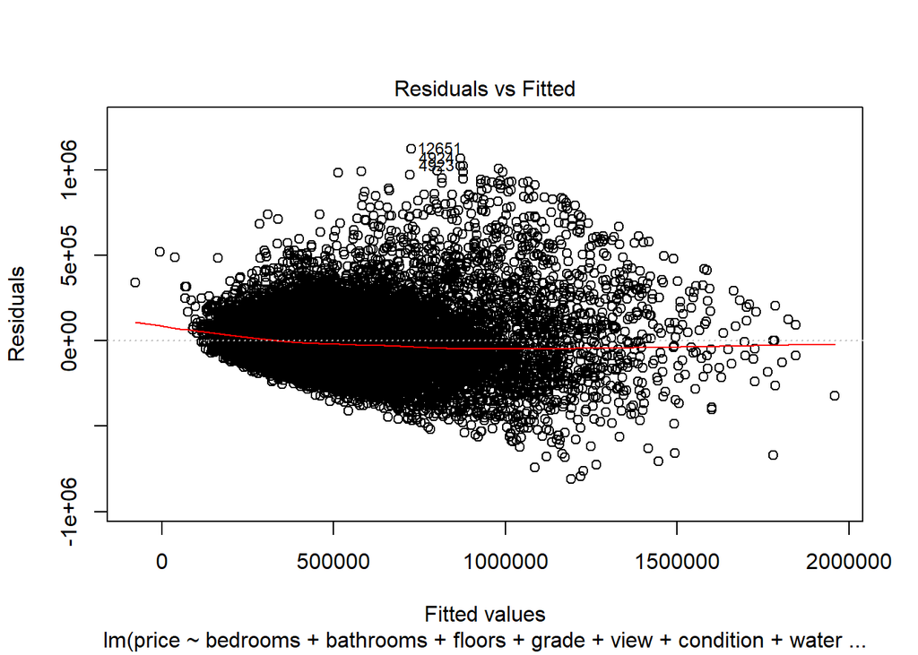

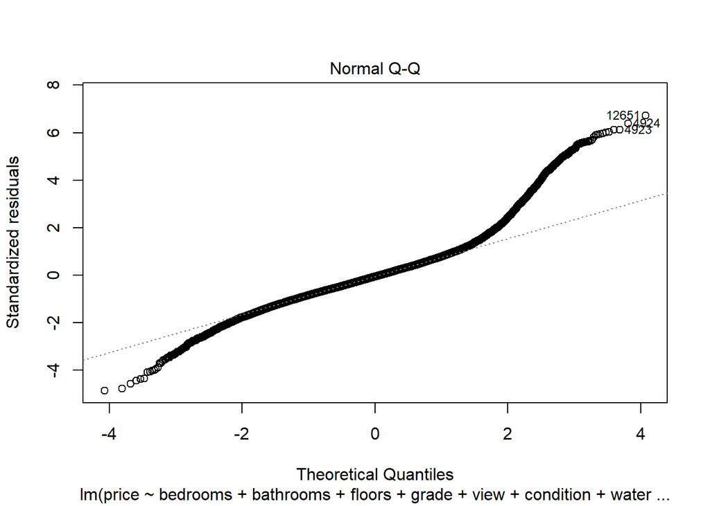

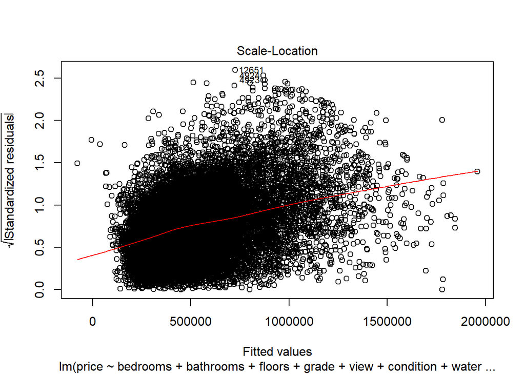

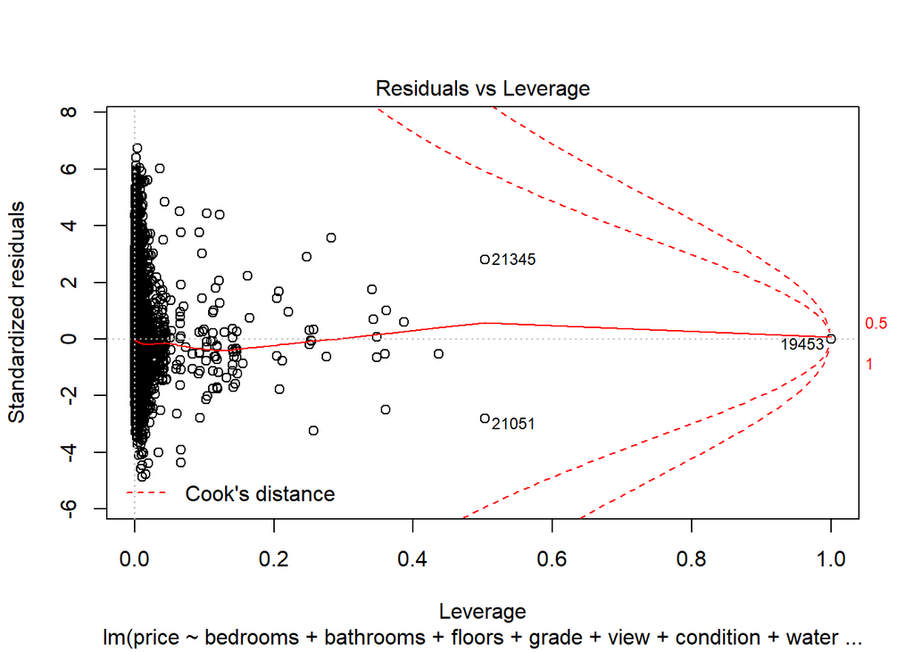

### Model 5

```
##
## Call:
## lm(formula = price ~ view + bedrooms + bathrooms + sqft_living +
##     sqft_lot + waterfront + condition + grade + yr_built + yr_renovated +
##     sqft_living15 + sqft_lot15 + floors, data = house)
##
## Residuals:
##     Min      1Q  Median      3Q     Max
## -805582  -99902  -10726   81214 1104036
##
## Coefficients:
##                Estimate Std. Error t value Pr(>|t|)
## (Intercept)    5.59e+06   2.09e+05   26.77  < 2e-16 ***
## view1          9.04e+04   9.57e+03    9.45  < 2e-16 ***
## view2          5.04e+04   5.77e+03    8.74  < 2e-16 ***
## view3          1.00e+05   7.97e+03   12.56  < 2e-16 ***
## view4          1.93e+05   1.28e+04   15.03  < 2e-16 ***
## bedrooms1      3.20e+04   6.35e+04    0.50  0.61457
## bedrooms2      4.88e+04   6.29e+04    0.78  0.43708
## bedrooms3      1.13e+04   6.28e+04    0.18  0.85703
## bedrooms4     -5.66e+03   6.29e+04   -0.09  0.92826
## bedrooms5     -1.67e+03   6.30e+04   -0.03  0.97885
## bedrooms6     -3.82e+04   6.38e+04   -0.60  0.54947
## bedrooms7     -9.04e+04   6.98e+04   -1.30  0.19529
## bedrooms8      6.75e+04   8.09e+04    0.83  0.40395
## bedrooms9      1.31e+04   9.85e+04    0.13  0.89423
## bedrooms10     3.77e+04   1.17e+05    0.32  0.74753
## bedrooms11    -1.81e+05   1.79e+05   -1.01  0.31145
## bedrooms33     1.88e+05   1.79e+05    1.05  0.29281
## bathrooms0.5  -7.98e+04   1.15e+05   -0.70  0.48700
## bathrooms0.75 -4.19e+03   8.03e+04   -0.05  0.95836
## bathrooms1     4.02e+03   7.85e+04    0.05  0.95915
## bathrooms1.25  8.86e+04   9.63e+04    0.92  0.35758
## bathrooms1.5   1.54e+04   7.85e+04    0.20  0.84490
## bathrooms1.75  2.51e+04   7.85e+04    0.32  0.74948
## bathrooms2     2.85e+04   7.85e+04    0.36  0.71670
## bathrooms2.25  4.70e+04   7.85e+04    0.60  0.54963
## bathrooms2.5   2.81e+04   7.85e+04    0.36  0.72050
## bathrooms2.75  5.56e+04   7.86e+04    0.71  0.47980
## bathrooms3     6.75e+04   7.87e+04    0.86  0.39118
```

[output cut: 33 more lines]

```
## yr_built      -2.83e+03   6.35e+01  -44.51  < 2e-16 ***
## yr_renovated2  3.46e+04   6.24e+03    5.55  2.9e-08 ***
## sqft_living15  4.99e+01   2.91e+00   17.14  < 2e-16 ***
## sqft_lot15    -4.00e-01   6.12e-02   -6.53  6.8e-11 ***
## floors1.5      2.04e+04   4.48e+03    4.55  5.5e-06 ***
## floors2        2.17e+04   3.46e+03    6.28  3.4e-10 ***
## floors2.5      8.41e+04   1.44e+04    5.85  5.1e-09 ***
## floors3        1.36e+05   7.79e+03   17.47  < 2e-16 ***
## floors3.5      2.05e+05   6.42e+04    3.19  0.00141 **
## ---
## Signif. codes:  0 '***' 0.001 '**' 0.01 '*' 0.05 '.' 0.1 ' ' 1
##
## Residual standard error: 168000 on 21345 degrees of freedom
## Multiple R-squared:  0.662,  Adjusted R-squared:  0.661
## F-statistic:  606 on 69 and 21345 DF,  p-value: <2e-16
```

```
##   (Intercept)         view1         view2         view3         view4
##      5.59e+06      9.04e+04      5.04e+04      1.00e+05      1.93e+05
##     bedrooms1     bedrooms2     bedrooms3     bedrooms4     bedrooms5
##      3.20e+04      4.88e+04      1.13e+04     -5.66e+03     -1.67e+03
##     bedrooms6     bedrooms7     bedrooms8     bedrooms9    bedrooms10
##     -3.82e+04     -9.04e+04      6.75e+04      1.31e+04      3.77e+04
##    bedrooms11    bedrooms33  bathrooms0.5 bathrooms0.75    bathrooms1
##     -1.81e+05      1.88e+05     -7.98e+04     -4.19e+03      4.02e+03
## bathrooms1.25  bathrooms1.5 bathrooms1.75    bathrooms2 bathrooms2.25
##      8.86e+04      1.54e+04      2.51e+04      2.85e+04      4.70e+04
##  bathrooms2.5 bathrooms2.75    bathrooms3 bathrooms3.25  bathrooms3.5
##      2.81e+04      5.56e+04      6.75e+04      1.31e+05      1.26e+05
## bathrooms3.75    bathrooms4 bathrooms4.25  bathrooms4.5 bathrooms4.75
##      2.21e+05      1.40e+05      1.63e+05      1.60e+05      1.62e+05
##    bathrooms5 bathrooms5.25  bathrooms5.5 bathrooms5.75    bathrooms6
##      1.83e+05      2.02e+05      1.89e+05      1.16e+05     -4.61e+05
##  bathrooms6.5 bathrooms6.75  bathrooms7.5   sqft_living      sqft_lot
##      2.69e+04     -6.13e+05     -3.90e+04      9.04e+01      7.60e-02
##   waterfront1    condition2    condition3    condition4    condition5
##      2.27e+05      9.37e+03      4.55e+04      6.14e+04      1.05e+05
##        grade3        grade4        grade5        grade6        grade7
##     -7.44e+04     -1.17e+05     -1.30e+05     -7.45e+04      2.21e+04
##        grade8        grade9       grade10       grade11       grade12
##      1.18e+05      2.60e+05      3.93e+05      5.09e+05      7.36e+05
##       grade13      yr_built yr_renovated2 sqft_living15    sqft_lot15
##      9.34e+05     -2.83e+03      3.46e+04      4.99e+01     -4.00e-01
##     floors1.5       floors2     floors2.5       floors3     floors3.5
##      2.04e+04      2.17e+04      8.41e+04      1.36e+05      2.05e+05
```

```
##                   2.5 %    97.5 %
## (Intercept)    5.18e+06  6.00e+06
## view1          7.17e+04  1.09e+05
## view2          3.91e+04  6.17e+04
## view3          8.44e+04  1.16e+05
## view4          1.68e+05  2.18e+05
## bedrooms1     -9.24e+04  1.56e+05
## bedrooms2     -7.44e+04  1.72e+05
## bedrooms3     -1.12e+05  1.34e+05
## bedrooms4     -1.29e+05  1.18e+05
## bedrooms5     -1.25e+05  1.22e+05
## bedrooms6     -1.63e+05  8.69e+04
## bedrooms7     -2.27e+05  4.64e+04
## bedrooms8     -9.10e+04  2.26e+05
## bedrooms9     -1.80e+05  2.06e+05
## bedrooms10    -1.92e+05  2.67e+05
## bedrooms11    -5.33e+05  1.70e+05
## bedrooms33    -1.63e+05  5.39e+05
## bathrooms0.5  -3.05e+05  1.45e+05
## bathrooms0.75 -1.62e+05  1.53e+05
## bathrooms1    -1.50e+05  1.58e+05
## bathrooms1.25 -1.00e+05  2.77e+05
## bathrooms1.5  -1.39e+05  1.69e+05
## bathrooms1.75 -1.29e+05  1.79e+05
## bathrooms2    -1.25e+05  1.82e+05
## bathrooms2.25 -1.07e+05  2.01e+05
## bathrooms2.5  -1.26e+05  1.82e+05
## bathrooms2.75 -9.85e+04  2.10e+05
## bathrooms3    -8.68e+04  2.22e+05
## bathrooms3.25 -2.36e+04  2.85e+05
## bathrooms3.5  -2.82e+04  2.81e+05
## bathrooms3.75  6.48e+04  3.78e+05
## bathrooms4    -1.72e+04  2.97e+05
## bathrooms4.25  3.19e+03  3.23e+05
## bathrooms4.5   2.08e+03  3.18e+05
## bathrooms4.75 -2.39e+04  3.48e+05
## bathrooms5     8.05e+03  3.58e+05
## bathrooms5.25  1.14e+04  3.92e+05
## bathrooms5.5  -3.85e+04  4.16e+05
## bathrooms5.75 -1.31e+05  3.64e+05
```

[output cut: 16 more lines]

```
## grade8        -2.39e+05  4.74e+05
## grade9        -9.66e+04  6.17e+05
## grade10        3.64e+04  7.50e+05
## grade11        1.52e+05  8.66e+05
## grade12        3.76e+05  1.09e+06
## grade13        4.49e+05  1.42e+06
## yr_built      -2.95e+03 -2.70e+03
## yr_renovated2  2.24e+04  4.68e+04
## sqft_living15  4.42e+01  5.56e+01
## sqft_lot15    -5.20e-01 -2.80e-01
## floors1.5      1.16e+04  2.92e+04
## floors2        1.49e+04  2.85e+04
## floors2.5      5.59e+04  1.12e+05
## floors3        1.21e+05  1.51e+05
## floors3.5      7.91e+04  3.31e+05
```

```
##         view1         view2         view3         view4     bedrooms1
##          1.03          1.06          1.07          1.47         28.25
##     bedrooms2     bedrooms3     bedrooms4     bedrooms5     bedrooms6
##        337.96        746.43        652.18        202.47         37.20
##     bedrooms7     bedrooms8     bedrooms9    bedrooms10    bedrooms11
##          5.71          2.56          2.07          1.46          1.14
##    bedrooms33  bathrooms0.5 bathrooms0.75    bathrooms1 bathrooms1.25
##          1.14          1.88         16.48        692.89          2.97
##  bathrooms1.5 bathrooms1.75    bathrooms2 bathrooms2.25  bathrooms2.5
##        296.01        573.15        385.37        405.36        881.36
## bathrooms2.75    bathrooms3 bathrooms3.25  bathrooms3.5 bathrooms3.75
##        245.45        156.88        120.16        151.98         31.97
##    bathrooms4 bathrooms4.25  bathrooms4.5 bathrooms4.75    bathrooms5
##         26.56         14.16         20.30          3.20          4.53
## bathrooms5.25  bathrooms5.5 bathrooms5.75    bathrooms6  bathrooms6.5
##          3.02          1.91          1.70          1.48          1.23
## bathrooms6.75  bathrooms7.5   sqft_living      sqft_lot   waterfront1
##          1.26          1.42          5.21          2.09          1.44
##    condition2    condition3    condition4    condition5        grade3
##          6.90        171.69        146.27         54.94          4.40
##        grade4        grade5        grade6        grade7        grade8
##         35.00        281.98       2170.15       6135.30       5116.27
##        grade9       grade10       grade11       grade12       grade13
##       2688.47       1204.19        383.17         67.91          2.19
##      yr_built yr_renovated2 sqft_living15    sqft_lot15     floors1.5
##          2.64          1.17          2.89          2.13          1.24
##       floors2     floors2.5       floors3     floors3.5
##          2.14          1.05          1.28          1.02
```

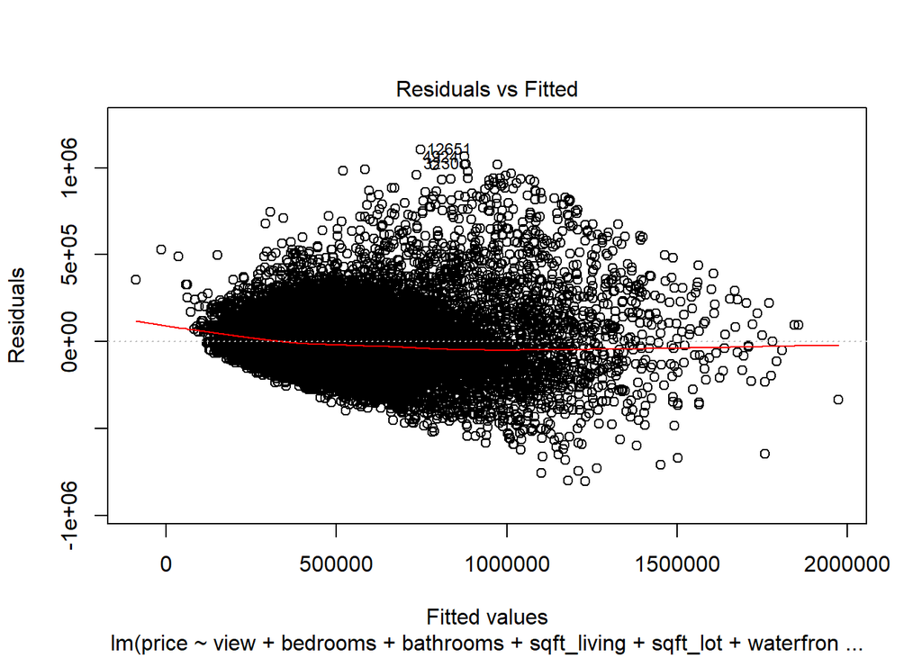

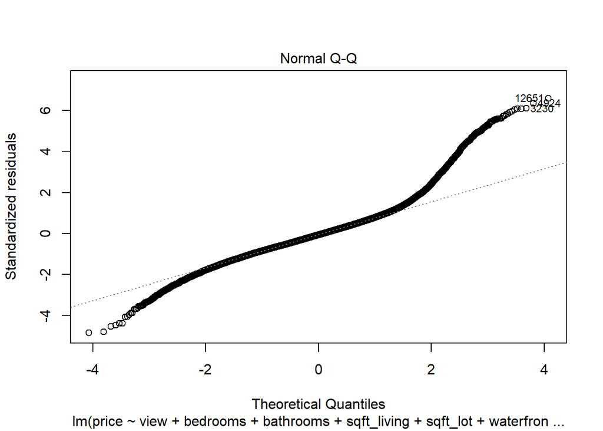

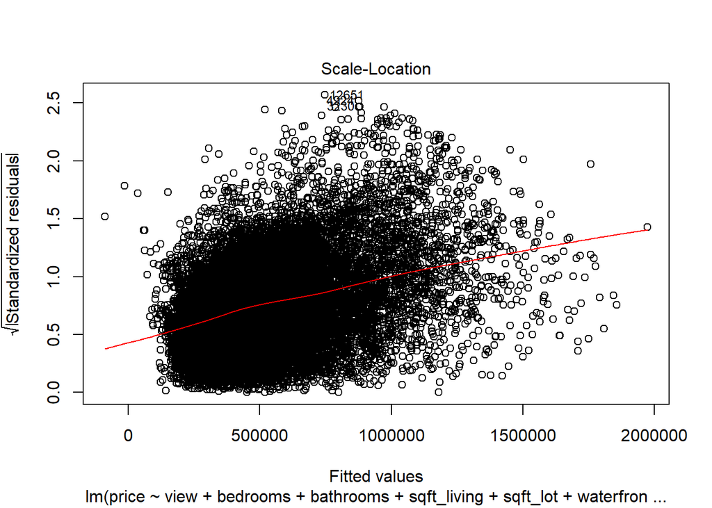

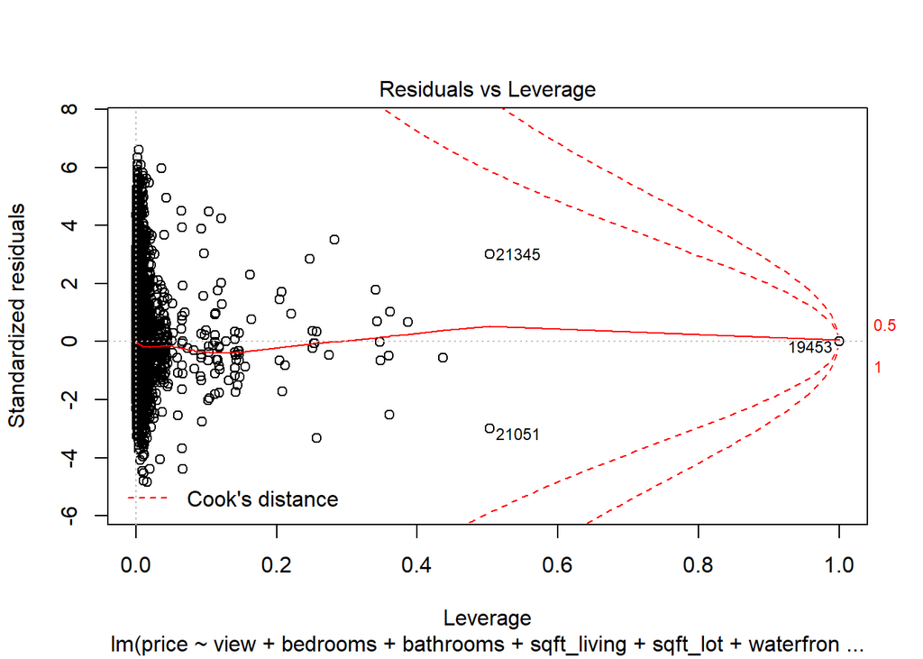

R2 is about 66% thus model explains 66% of results in data. Removed sqft above because of moderately high VIF at 7.1. A moderately high VIF at 5 for sqft living - not high enough for concern. Square feet living dropped from 8 to 5 when removing Sq ft above. I took out sqft basement b/c of high VIF value over 20. Upper ends and scores of condition, grade, and bathrooms were significant but not lower levels. Square feet living, square feet lot, waterfront, year built, year renovated, Sq feet living and lot of surrounding 15 houses average, and all factor levels of floor and view were statistically significant. Bedrooms, however, were consistently not significant. Bedrooms are possibly insignificant because overall square foot has more effect than number of bedrooms or there is multicollinearity present. A few notable results from the model: as bedrooms increase price tends to decrease, yr built is also negatively correlated with price, as is sq ft of surrounding lots.We also removed zip code, latitude, and longitude becasue they weren’t properly measurable and didn’t explain price well. Although this model has a lower R2 than the model above with all the variables, it makes more sense for analytic purposes and explaining the target variable.